# Utiliser R et le package `limma` après une recherche MaxQuant pour l’analyse de PTM

Ecole thématique CNRS 2026 - Sète

# 1. Objectif du tutoriel

Dans les études de modifications post-traductionnelles (PTM), comme la phosphorylation, une variation d’abondance observée pour un peptide modifié ne traduit pas nécessairement une régulation spécifique de la modification. Elle peut simplement refléter une variation d’abondance de la protéine à laquelle ce peptide appartient.

L’objectif de ce tutoriel est de montrer comment construire, à partir de sorties MaxQuant, une analyse avec limma permettant de distinguer les variations globales de protéines des variations spécifiques au peptide modifié.

Nous utilisons pour cela un jeu de données public disponible sur PRIDE (PXD020019), correspondant à une étude protéomique de cellules infectées par le SARS-CoV-2.

Ce dataset contient :

- des échantillons enrichis en phosphorylation ;
- des échantillons enrichis en ubiquitination ;
- des échantillons non enrichis pour la quantification protéique globale.

Ici, nous nous concentrons sur l’analyse des phosphopeptides.

# 2. Idée statistique

Nous allons comparer, pour chaque peptide modifié, les intensités du phosphopeptide aux intensités de sa protéine d’appartenance.

Au lieu d’analyser séparément chaque condition, nous allons construire un modèle global intégrant simultanément :

- le **composant** : `PROT` ou `PTM` ;
- la **condition** : `mock` ou `SARS_COV_2` ;
- le **temps** : `6h` ou `24h`.

Le modèle contient donc les interactions entre ces facteurs. Cela permet de tester plusieurs hypothèses biologiques.

En particulier, le terme d’interaction `CompPTM:ConditionSARS_COV_2:Time24h` mesure si la variation du PTM entre `6h` et `24h`, relativement à sa protéine, est différente entre `mock` et `SARS_COV_2`.

Tester la nullité du coefficient lié à cette interaction permet de répondre à la question:

> “la dynamique temporelle du PTM relativement à la protéine dépend-elle de l’infection ?”

# 3. Packages nécessaires

## 3.1 Installation

On installe les packages nécessaires si besoin. Ce n’est à exécuter qu’une seule fois par machine.

Voici ce que fait chaque package:

- BiocManager : permet d’installer les packages dispo sur Bioconductor (packages uniquement bioinformatiques). Il est conseillé d’installer la dernière version disponible.
- limma : estime des modèles linéaires adaptés aux données omiques et permet d’effectuer des t-tests modérés
- data.table : lecture rapide de gros jeux de données (fread)
- ggplot2 : permet de créer des graphiques pour publications
- reshape2 : permet de reformater des data frames d’un format long à un format large (nécessaire pour ggplot2)
- stringi : permet de faire de la manipulation de chaines de caractères
- ggridges : permet de faire des plots “ridge” (pour l’affichage des densités d’intensité par échantillons)

```r
if (!require("BiocManager", quietly = TRUE))
  install.packages("BiocManager")
BiocManager::install("limma")

install.packages("data.table")
install.packages("ggplot2")
install.packages("reshape2")
install.packages("stringi")
install.packages("ggridges")
```

## 3.2 Chargement

Nous chargeons ici les packages utilisés dans la session R utilisée (après leur installation, ils ne sont pas chargés automatiquement dans la session).

```r
library(limma)
library(data.table)
library(ggplot2)
library(reshape2)
library(stringi)
library(ggridges)
```

# 4. Import des sorties MaxQuant

Nous téléchargeons directement depuis PRIDE les deux fichiers utilisés dans l’analyse :

- `proteinGroups.txt` pour les protéines ;
- `PhosphoSTYSites.txt` pour les peptides phosphorylés.

Nous remplaçons ensuite les espaces par des points dans les noms de colonnes, afin de faciliter leur manipulation dans R. fread() est comme read.table() mais beaucoup plus rapide pour des gros fichiers. Après chargement, on remplace les espaces dans les noms de colonnes par des points pour une manipulation plus facile depuis R (e.g., “Protein IDs” devient “Protein.IDs”).

```r
data.prot <- fread("https://ftp.pride.ebi.ac.uk/pride/data/archive/2020/07/PXD020019/proteinGroups.txt")
data.ptm  <- fread("https://ftp.pride.ebi.ac.uk/pride/data/archive/2020/07/PXD020019/PhosphoSTYSites.txt")

setnames(data.prot, gsub(" ", ".", names(data.prot), fixed = TRUE))
setnames(data.ptm,  gsub(" ", ".", names(data.ptm),  fixed = TRUE))
```

## 4.1 Inspection rapide

Cette commande permet de vérifier rapidement la taille des deux jeux de données importés.  
Elle renvoie le nombre de lignes et de colonnes, ce qui donne une première idée du volume de données disponible pour l’analyse.

```r
dim(data.prot)
```

```
## [1] 8742  295
```

```r
dim(data.ptm)
```

```
## [1] 22168   579
```

Avant de filtrer ou de restructurer les données, il est utile d’inspecter les noms de colonnes.  
Cela permet de repérer les variables d’annotation, les colonnes d’intensités, et de vérifier que les noms utilisés dans le code correspondent bien à ceux des fichiers MaxQuant.

```r
colnames(data.prot)
colnames(data.ptm)
```

# 5. Préparation des données

## 5.1 Filtrer les identifications non retenues

Comme classiquement avec MaxQuant, nous retirons ici deux types d’identifications qui ne doivent généralement pas être conservées pour l’analyse statistique :

- les entrées `Reverse`, utilisées pour estimer le taux de faux positifs ;
- les `Potential contaminant`, correspondant à des contaminants connus.

Ce filtrage est une étape standard de pré-traitement. Comme les protéines associées sont indiquées par “+”, on effectue la commande suivante:

```r
data.ptm <- data.ptm[
  which((data.ptm$Reverse != "+") & (data.ptm$Potential.contaminant != "+")),
]
```

## 5.2 Filtrer les sites bien localisés

Tous les peptides modifiés identifiés ne présentent pas nécessairement une localisation fiable de la modification.  
Ici, nous conservons uniquement les sites pour lesquels la probabilité de localisation est supérieure à 0.75.  
Cela permet de se concentrer sur des peptides modifiés dont l’interprétation biologique est fiable.

```r
data.ptm <- data.ptm[which(data.ptm$Localization.prob > 0.75), ]
```

## 5.3 Construire la matrice PTM

Nous extrayons ici la matrice d’intensités des phosphopeptides à partir des colonnes contenant `Intensity.Phospho`.  
Dans les sorties MaxQuant, les zéros correspondent en pratique à des valeurs manquantes pour l’analyse quantitative ; nous les remplaçons donc par `NA`.  
Enfin, nous convertissons toutes les colonnes en objet “numérique” afin de pouvoir appliquer les traitements statistiques ultérieurs.

```r
int.ptm <- as.data.frame(data.ptm)[, grep("Intensity.Phospho", names(data.ptm))]
int.ptm[int.ptm == 0] <- NA
int.ptm <- as.data.frame(lapply(int.ptm, as.numeric))
```

### 5.3.1 Gérer les multiplicités

Dans les sorties MaxQuant, les intensités correspondant à des peptides porteurs d’une, deux, ou trois ou plus modifications sont séparées par les suffixes :

- `___1`
- `___2`
- `___3`

Nous reconstruisons une matrice unique en empilant ces trois blocs de données.  
Nous conservons en parallèle trois informations essentielles :

- l’identifiant du peptide modifié ;
- l’identifiant du groupe protéique ;
- la multiplicité de modification.

Cette restructuration est importante, car elle permet d’analyser ensuite chaque combinaison peptide x multiplicité comme une entité quantitative distincte.

```r
#Création de trois matrices, chacune caractérisée par le nombre de modifications
mat1 <- int.ptm[, grep("___1", colnames(int.ptm))]
mat2 <- int.ptm[, grep("___2", colnames(int.ptm))]
mat3 <- int.ptm[, grep("___3", colnames(int.ptm))]

#Standardisation des noms des colonnes des trois matrices
colnames(mat1) <- gsub("___1", "", colnames(mat1))
colnames(mat2) <- gsub("___2", "", colnames(mat2))
colnames(mat3) <- gsub("___3", "", colnames(mat3))

#On met bout à bout les trois matrices (chacune en dessous de l'autre)
int.ptm.mod <- rbind(mat1, mat2, mat3)

#On créé les vecteurs contenant les identifiants des PTMs, protéines et la multiplicité (nombre de PTMs associés)
id.ptm <- rep(data.ptm$id, 3)
id.pg  <- rep(data.ptm$Protein.group.IDs, 3)
multiplicity <- c(
  rep("___1", nrow(int.ptm)),
  rep("___2", nrow(int.ptm)),
  rep("___3", nrow(int.ptm))
)
```

### 5.3.2 Retirer les lignes sans quantification

Certaines lignes de la matrice PTM ne contiennent aucune intensité observée.  
Ces lignes ne peuvent pas contribuer à l’analyse statistique et sont donc supprimées.  
Nous appliquons le même filtrage aux vecteurs d’annotation associés (id.ptm, id.pg, multiplicity) afin de conserver la cohérence entre les données et leurs métadonnées.

```r
sum_notna <- apply(int.ptm.mod, 1, function(x) sum(!is.na(x)))

int.ptm.mod <- int.ptm.mod[which(sum_notna > 0), ]
id.ptm <- id.ptm[which(sum_notna > 0)]
id.pg <- id.pg[which(sum_notna > 0)]
multiplicity <- multiplicity[which(sum_notna > 0)]
```

### 5.3.3 Renommer les colonnes

Nous simplifions ici les noms de colonnes pour rendre les tableaux et graphiques plus lisibles.  
Nous construisons ensuite un objet unique qui contient à la fois :

- les identifiants du peptide modifié ;
- les identifiants de protéines ;
- la multiplicité ;
- les intensités.

Cet objet servira de base aux étapes d’appariement avec les protéines.

```r
short.name <- unlist(strsplit(colnames(int.ptm.mod), split = "Intensity.Phospho_"))
short.name <- short.name[short.name != ""]
colnames(int.ptm.mod) <- short.name

data.ptm.mod <- data.frame(
  id.ptm = id.ptm,
  id.pg = id.pg,
  multiplicity = multiplicity,
  int.ptm.mod,
  check.names = FALSE
)

head(data.ptm.mod[, 1:8])
```

```
##    id.ptm id.pg multiplicity mock_24h_1 mock_24h_2 mock_24h_3 mock_6h_1
## 7       7    14         ___1         NA         NA         NA        NA
## 12     17    17         ___1   33764000         NA         NA        NA
## 13     18    17         ___1         NA         NA         NA        NA
## 15     20    17         ___1   43529000   43061000   32908000  12194000
## 16     22    17         ___1   22813000   22699000         NA  17064000
## 17     23    17         ___1   19454000   16233000   18756000        NA
##    mock_6h_2
## 7   33263000
## 12        NA
## 13        NA
## 15  14142000
## 16  25739000
## 17        NA
```

## 5.4 Construire la matrice protéines

Nous construisons ici la matrice d’intensités protéiques à partir de `proteinGroups.txt`.  
Les colonnes correspondant aux fractions enrichies en PTM sont retirées, car nous voulons quantifier ici les protéines à partir des échantillons non enrichis.  
Comme précédemment, les zéros sont remplacés par `NA`, puis les colonnes sont converties en objet “numérique”.  
Nous ajoutons enfin l’identifiant de groupe protéique, qui sera utilisé pour l’appariement avec les peptides modifiés.

```r
int.prot <- as.data.frame(data.prot)[, grep("Intensity.", names(data.prot))]

int.prot <- int.prot[, !names(int.prot) %in% grep("Phospho", names(int.prot), value = TRUE)]
int.prot <- int.prot[, !names(int.prot) %in% grep("Ubi", names(int.prot), value = TRUE)]

int.prot[int.prot == 0] <- NA
int.prot <- as.data.frame(lapply(int.prot, as.numeric))

data.prot.mod <- data.frame(
  id.pg = data.prot$id,
  int.prot,
  check.names = FALSE
)
```

# 6. Définir le plan expérimental

Le package R “limma” nécessite de savoir quel échantillon appartient à quel groupe expérimental. Il faut lui fournir une matrice de “design” et une matrice de “contraste”. La matrice de “design” caractérise le design expérimental. La matrice de “contraste” caractérise quelles conditions vont être comparées (c.à.d. le test statistique utilisé).

Dans notre cas:

- PTM : 12 colonnes = 2 conditions × 2 temps × 3 répétitions ;
- protéines : 16 colonnes = 2 conditions × 2 temps × 4 répétitions.

L’étape de la définition du design expérimental est essentielle, car toute la modélisation statistique repose sur un bon codage du design expérimental.

## 6.1 Design PTM

Nous définissons ici, pour chaque colonne PTM :

- la condition biologique ;
- le temps ;
- et leur combinaison.

```r
Cond.ptm <- factor(c(rep("mock", 6), rep("SARS_COV_2", 6)),
                   levels = c("mock", "SARS_COV_2"))

Time.ptm <- factor(rep(c(rep("24h", 3), rep("6h", 3)), 2),
                   levels = c("6h", "24h"))

CondTime.ptm <- factor(paste(Cond.ptm, Time.ptm, sep = "_"))

data.frame(
  sample = colnames(int.ptm.mod),
  condition = Cond.ptm,
  time = Time.ptm,
  group = CondTime.ptm
)
```

```
##             sample  condition time          group
## 1       mock_24h_1       mock  24h       mock_24h
## 2       mock_24h_2       mock  24h       mock_24h
## 3       mock_24h_3       mock  24h       mock_24h
## 4        mock_6h_1       mock   6h        mock_6h
## 5        mock_6h_2       mock   6h        mock_6h
## 6        mock_6h_3       mock   6h        mock_6h
## 7  SARS_COV2_24h_1 SARS_COV_2  24h SARS_COV_2_24h
## 8  SARS_COV2_24h_2 SARS_COV_2  24h SARS_COV_2_24h
## 9  SARS_COV2_24h_3 SARS_COV_2  24h SARS_COV_2_24h
## 10  SARS_COV2_6h_1 SARS_COV_2   6h  SARS_COV_2_6h
## 11  SARS_COV2_6h_2 SARS_COV_2   6h  SARS_COV_2_6h
## 12  SARS_COV2_6h_3 SARS_COV_2   6h  SARS_COV_2_6h
```

## 6.2 Design protéines

Nous faisons de même pour les colonnes protéiques. Ici, on a quatre réplicats au lieu de 3.  
Il est important de vérifier que l’ordre supposé des échantillons correspond bien à l’ordre des colonnes importées.

```r
Cond.prot <- factor(c(rep("mock", 8), rep("SARS_COV_2", 8)),
                    levels = c("mock", "SARS_COV_2"))

Time.prot <- factor(rep(c(rep("24h", 4), rep("6h", 4)), 2),
                    levels = c("6h", "24h"))

CondTime.prot <- factor(paste(Cond.prot, Time.prot, sep = "_"))

data.frame(
  sample = colnames(int.prot),
  condition = Cond.prot,
  time = Time.prot,
  group = CondTime.prot
)
```

```
##                       sample  condition time          group
## 1       Intensity.mock_24h_1       mock  24h       mock_24h
## 2       Intensity.mock_24h_2       mock  24h       mock_24h
## 3       Intensity.mock_24h_3       mock  24h       mock_24h
## 4       Intensity.mock_24h_4       mock  24h       mock_24h
## 5        Intensity.mock_6h_1       mock   6h        mock_6h
## 6        Intensity.mock_6h_2       mock   6h        mock_6h
## 7        Intensity.mock_6h_3       mock   6h        mock_6h
## 8        Intensity.mock_6h_4       mock   6h        mock_6h
## 9  Intensity.SARS_COV2_24h_1 SARS_COV_2  24h SARS_COV_2_24h
## 10 Intensity.SARS_COV2_24h_2 SARS_COV_2  24h SARS_COV_2_24h
## 11 Intensity.SARS_COV2_24h_3 SARS_COV_2  24h SARS_COV_2_24h
## 12 Intensity.SARS_COV2_24h_4 SARS_COV_2  24h SARS_COV_2_24h
## 13  Intensity.SARS_COV2_6h_1 SARS_COV_2   6h  SARS_COV_2_6h
## 14  Intensity.SARS_COV2_6h_2 SARS_COV_2   6h  SARS_COV_2_6h
## 15  Intensity.SARS_COV2_6h_3 SARS_COV_2   6h  SARS_COV_2_6h
## 16  Intensity.SARS_COV2_6h_4 SARS_COV_2   6h  SARS_COV_2_6h
```

# 7. Contrôle qualité rapide

Avant de passer à la modélisation, il est important de vérifier rapidement que les données présentent une structure cohérente et qu’aucun échantillon ne semble aberrant.

## 7.1 Transformation log2

Les intensités des protéines sont généralement analysées après transformation logarithmique en base 2.  
Cette transformation permet :

- de réduire l’asymétrie des distributions ;
- de stabiliser la variance des intensités (les intensités plus élevées ayant une variance initialement plus élevées, ce qui peut impacter le test statistique);
- d’interpréter plus facilement les différences comme des changements relatifs.

C’est une étape standard avant l’application de modèles linéaires.

```r
log2.int.ptm <- log2(as.matrix(int.ptm.mod))
log2.int.prot <- log2(as.matrix(int.prot))
```

## 7.2 Distribution des intensités PTM

Nous visualisons ici la distribution des intensités log2 des phosphopeptides, en nous limitant aux peptides observés dans tous les échantillons PTM.  
L’objectif est de vérifier si les distributions sont globalement comparables entre échantillons.  
De fortes différences de position ou de forme peuvent signaler un problème de normalisation ou un échantillon aberrant.

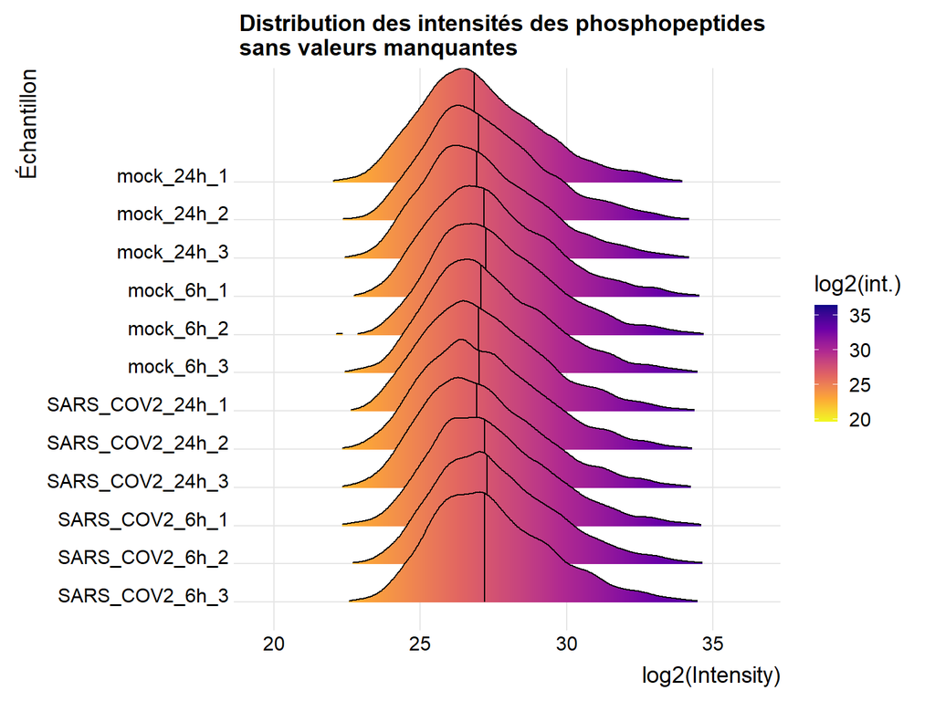

```r
# Calculer le nombre de valeurs observées sur chaque ligne
sum_notna_ptm <- apply(log2.int.ptm, 1, function(x) sum(!is.na(x)))

# Conserver les phosphopeptides observés dans tous les échantillons PTM
log2.int.ptm.complete <- log2.int.ptm[sum_notna_ptm == ncol(log2.int.ptm), ]

# Mise en forme d'un dataset avec une colonne par échantillon, en un data.frame long (une ligne par protéine)
df.ptm <- melt(log2.int.ptm.complete)
colnames(df.ptm) <- c("Feature", "Sample", "log2Intensity")

# On renverse l'ordre d'affichage des échantillons
df.ptm$Sample <- factor(df.ptm$Sample, levels = rev(colnames(log2.int.ptm.complete)))

ggplot(df.ptm, aes(x = log2Intensity, y = Sample, fill = after_stat(x))) +
  stat_density_ridges(
    geom = "density_ridges_gradient",
    scale = 3,
    size = 0.3,
    rel_min_height = 0.01,
    quantile_lines = TRUE,
    quantiles = 2,
    alpha = 0.7
  ) +
  scale_fill_viridis_c(
    name = "log2(int.)",
    option = "C",
    direction = -1
  ) +
  theme_ridges() +
  labs(
    title = "Distribution des intensités des phosphopeptides\nsans valeurs manquantes",
    x = "log2(Intensity)",
    y = "Échantillon"
  )
```

## 7.3 Corrélation entre échantillons PTM

Cette matrice de corrélation permet d’évaluer la similarité globale entre échantillons. Ici, la corrélation entre 2 échantillons n’est évaluée qu’avec les valeurs quantifiées entre les 2 échantillons (“pairwise.complete.obs”). Des corrélations élevées sont attendues entre répétitions biologiques d’une même condition.  
Cette visualisation constitue un contrôle qualité simple pour détecter d’éventuels échantillons atypiques (leurs valeurs quantifiées ne corrèlent pas).

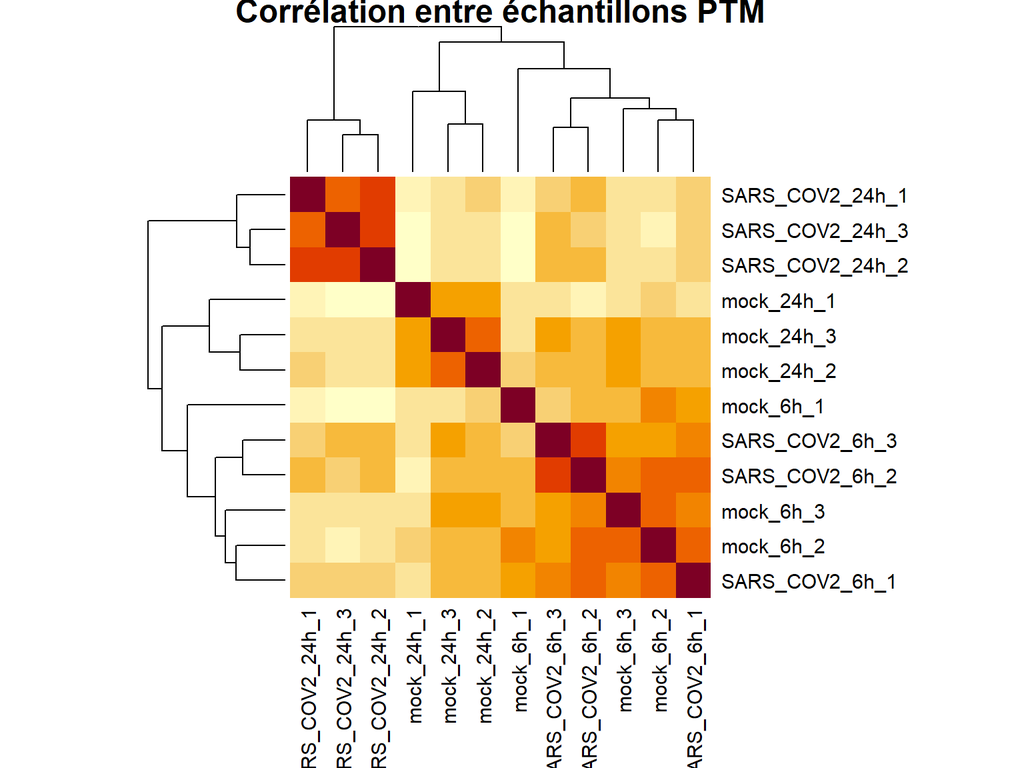

```r
cor.ptm <- cor(log2.int.ptm, use = "pairwise.complete.obs")

heatmap(
  cor.ptm,
  symm = TRUE,
  margins = c(8, 8),
  main = "Corrélation entre échantillons PTM"
)
```

# 8. Normalisation simple

Une étape de normalisation est généralement nécessaire pour corriger les décalages globaux entre échantillons avant d’interpréter les différences biologiques.

Des petites différences d’intensité systématiques peuvent exister entre échantillons (par exemple à cause de gammes dynamiques légèrement différentes). Une normalisation “légère” peut permettre de corriger ces “shifts” globaux tout en préservant les différences biologiques.

## 8.1 Fonction de normalisation par médiane

Nous définissons ici une fonction de normalisation simple par centrage de la médiane au sein de chaque groupe biologique.  
L’idée est de corriger des décalages globaux entre réplicats d’une même condition, tout en conservant la structure biologique de l’expérience.

```r
median.norm <- function(intensities, condition){
  int.norm <- intensities
  lev <- levels(condition)
  medianes <- rep(0, ncol(intensities))

  for (i in seq_along(lev)) {
    col_cond <- which(condition == lev[i])

    nbna_cond <- apply(
      intensities[, col_cond, drop = FALSE],
      1,
      function(x) sum(is.na(x))
    )

    medianes[col_cond] <- apply(
      intensities[which(nbna_cond == 0), col_cond, drop = FALSE],
      2,
      median,
      na.rm = TRUE
    )

    moy <- mean(medianes[col_cond], na.rm = TRUE)

    for (j in col_cond) {
      int.norm[, j] <- intensities[, j] - medianes[j] + moy
    }
  }

  return(int.norm)
}
```

## 8.2 Appliquer la normalisation

Nous appliquons ici la fonction de normalisation aux échantillons enrichis en PTM et aux échantillons de protéomique globale.  
À partir de cette étape, nous travaillons sur les intensités log2 normalisées.

```r
log2.int.ptm.norm  <- median.norm(log2.int.ptm,  CondTime.ptm)
log2.int.prot.norm <- median.norm(log2.int.prot, CondTime.prot)
```

# 9. Apparier les PTM à leurs protéines

La comparaison entre peptide modifié et protéine suppose un appariement explicite entre les deux niveaux d’information. C’est cette mise en correspondance qui permet ensuite de poser la bonne question statistique (c.à.d. de bien définir la matrice de contraste à tester).

## 9.1 Fonction d’appariement

La colonne `Protein.group.IDs` de MaxQuant peut contenir plusieurs identifiants séparés par des points-virgules.  
Nous définissons ici une fonction simple permettant de récupérer, pour chaque peptide modifié, le premier identifiant de groupe protéique qui correspond effectivement à une entrée du tableau `proteinGroups.txt`.

```r
prot_ids_available <- as.character(data.prot.mod$id.pg)

extract_first_matching_pg <- function(pg_string, available_ids) {
  ids <- unlist(strsplit(as.character(pg_string), ";", fixed = TRUE))
  ids <- trimws(ids)
  match_id <- ids[ids %in% available_ids]
  if (length(match_id) == 0) return(NA)
  match_id[1]
}
```

## 9.2 Apparier les identifiants

Nous appliquons la fonction d’appariement à tous les peptides modifiés.  
Pour simplifier, les peptides ne pouvant pas être reliés à une protéine quantifiée sont exclus de la suite de cette analyse. Cela garantit que toute comparaison PTM versus protéine repose sur un “match” explicite. En pratique, on peut cependant exporter ces peptides dans des fichiers séparés pour un examen ultérieur.

```r
mapped_pg <- sapply(
  as.character(data.ptm.mod$id.pg),
  extract_first_matching_pg,
  available_ids = prot_ids_available
)

keep_map <- !is.na(mapped_pg)

data.ptm.map <- data.ptm.mod[keep_map, ]
mapped_pg <- mapped_pg[keep_map]
log2.int.ptm.map <- log2.int.ptm.norm[keep_map, , drop = FALSE]
```

## 9.3 Extraire les profils protéiques associés

Une fois l’identifiant protéique associé à chaque peptide modifié déterminé, nous extrayons les profils d’intensité de la protéine correspondante.  
Nous construisons également une table d’annotation résumant :

- l’identifiant du peptide modifié ;
- l’identifiant protéique original ;
- l’identifiant protéique effectivement apparié ;
- la multiplicité.

```r
prot_index <- match(mapped_pg, as.character(data.prot.mod$id.pg))
log2.int.prot.map <- log2.int.prot.norm[prot_index, , drop = FALSE]

data.ptm.prot <- data.frame(
  id.ptm = data.ptm.map$id.ptm,
  id.pg.original = data.ptm.map$id.pg,
  id.pg.mapped = mapped_pg,
  multiplicity = data.ptm.map$multiplicity,
  stringsAsFactors = FALSE
)
```

# 10. Construire un modèle global PTM + protéine

Nous disposons maintenant de tous les éléments nécessaires pour construire un modèle global intégrant simultanément le type de composant, la condition biologique et le temps.

Nous allons maintenant empiler, pour chaque peptide modifié :

- les 12 intensités PTM ;
- les 16 intensités de la protéine associée.

Cela donne, pour chaque peptide, un vecteur de longueur 28.

## 10.1 Construire la matrice globale

Nous construisons ici, pour chaque peptide modifié, un profil global contenant :

- les intensités PTM ;
- les intensités de la protéine associée.

Chaque ligne de cette matrice correspond donc à un peptide modifié apparié à sa protéine, ce qui permet de modéliser explicitement les deux types de signaux dans un même cadre statistique.

```r
global.mat <- t(sapply(seq_len(nrow(log2.int.ptm.map)), function(i) {
  c(as.numeric(log2.int.ptm.map[i, ]),
    as.numeric(log2.int.prot.map[i, ]))
}))

rownames(global.mat) <- paste0(data.ptm.prot$id.ptm, "_", data.ptm.prot$multiplicity)

dim(global.mat)
```

```
## [1] 19990    28
```

```r
head(global.mat)
```

```
##             [,1]     [,2]     [,3]     [,4]     [,5] [,6]     [,7]     [,8]
## 7____1        NA       NA       NA       NA 24.92558   NA       NA       NA
## 17____1 25.06874       NA       NA       NA       NA   NA       NA       NA
## 18____1       NA       NA       NA       NA       NA   NA       NA       NA
## 20____1 25.43523 25.30142 24.97064 23.54618 23.69165   NA 25.34879 24.77070
## 22____1 24.50311 24.37766       NA 24.03096 24.55562   NA 24.24290       NA
## 23____1 24.27332 23.89396 24.15955       NA       NA   NA       NA 24.26612
##             [,9]    [,10]    [,11]    [,12]   [,13]    [,14]    [,15]    [,16]
## 7____1        NA       NA       NA 23.82855 28.4678 28.57709 27.43185 27.64196
## 17____1       NA 24.85012 25.67339       NA      NA       NA       NA       NA
## 18____1 27.28308       NA 27.32372 27.37883      NA       NA       NA       NA
## 20____1 24.79720 24.10088 24.13644 24.32183      NA       NA       NA       NA
## 22____1       NA       NA       NA       NA      NA       NA       NA       NA
## 23____1       NA       NA       NA       NA      NA       NA       NA       NA
##            [,17]    [,18]    [,19]    [,20]    [,21]    [,22]    [,23]    [,24]
## 7____1  27.97944 27.95916 27.82159 29.05347 28.97319 28.42888 28.22319 28.76038
## 17____1       NA       NA       NA       NA       NA       NA       NA       NA
## 18____1       NA       NA       NA       NA       NA       NA       NA       NA
## 20____1       NA       NA       NA       NA       NA       NA       NA       NA
## 22____1       NA       NA       NA       NA       NA       NA       NA       NA
## 23____1       NA       NA       NA       NA       NA       NA       NA       NA
##            [,25]    [,26]    [,27]    [,28]
## 7____1  28.42194 28.41901 27.57238 27.90356
## 17____1       NA       NA       NA       NA
## 18____1       NA       NA       NA       NA
## 20____1       NA       NA       NA       NA
## 22____1       NA       NA       NA       NA
## 23____1       NA       NA       NA       NA
```

## 10.2 Définir les facteurs globaux

Nous définissons maintenant les trois facteurs qui structurent l’analyse globale :

- `Comp` : type de composant (`PROT` ou `PTM`) ;
- `Condition` : `mock` ou `SARS_COV_2` ;
- `Time` : `6h` ou `24h`.

Ces facteurs décrivent chaque colonne de la matrice globale et serviront à construire la matrice de design du modèle linéaire.

```r
Comp <- factor(
  c(rep("PTM", ncol(log2.int.ptm.map)),
    rep("PROT", ncol(log2.int.prot.map))),
  levels = c("PROT", "PTM")
)

Condition <- factor(
  c(as.character(Cond.ptm), as.character(Cond.prot)),
  levels = c("mock", "SARS_COV_2")
)

Time <- factor(
  c(as.character(Time.ptm), as.character(Time.prot)),
  levels = c("6h", "24h")
)

data.frame(
  sample = c(colnames(log2.int.ptm.map), colnames(log2.int.prot.map)),
  Comp = Comp,
  Condition = Condition,
  Time = Time
)
```

```
##                       sample Comp  Condition Time
## 1                 mock_24h_1  PTM       mock  24h
## 2                 mock_24h_2  PTM       mock  24h
## 3                 mock_24h_3  PTM       mock  24h
## 4                  mock_6h_1  PTM       mock   6h
## 5                  mock_6h_2  PTM       mock   6h
## 6                  mock_6h_3  PTM       mock   6h
## 7            SARS_COV2_24h_1  PTM SARS_COV_2  24h
## 8            SARS_COV2_24h_2  PTM SARS_COV_2  24h
## 9            SARS_COV2_24h_3  PTM SARS_COV_2  24h
## 10            SARS_COV2_6h_1  PTM SARS_COV_2   6h
## 11            SARS_COV2_6h_2  PTM SARS_COV_2   6h
## 12            SARS_COV2_6h_3  PTM SARS_COV_2   6h
## 13      Intensity.mock_24h_1 PROT       mock  24h
## 14      Intensity.mock_24h_2 PROT       mock  24h
## 15      Intensity.mock_24h_3 PROT       mock  24h
## 16      Intensity.mock_24h_4 PROT       mock  24h
## 17       Intensity.mock_6h_1 PROT       mock   6h
## 18       Intensity.mock_6h_2 PROT       mock   6h
## 19       Intensity.mock_6h_3 PROT       mock   6h
## 20       Intensity.mock_6h_4 PROT       mock   6h
## 21 Intensity.SARS_COV2_24h_1 PROT SARS_COV_2  24h
## 22 Intensity.SARS_COV2_24h_2 PROT SARS_COV_2  24h
## 23 Intensity.SARS_COV2_24h_3 PROT SARS_COV_2  24h
## 24 Intensity.SARS_COV2_24h_4 PROT SARS_COV_2  24h
## 25  Intensity.SARS_COV2_6h_1 PROT SARS_COV_2   6h
## 26  Intensity.SARS_COV2_6h_2 PROT SARS_COV_2   6h
## 27  Intensity.SARS_COV2_6h_3 PROT SARS_COV_2   6h
## 28  Intensity.SARS_COV2_6h_4 PROT SARS_COV_2   6h
```

## 10.3 Construire la matrice de design globale

Nous construisons ici la matrice de design du modèle global.  
La formule `~ Comp * Condition * Time` inclut :

- les effets principaux ;
- toutes les interactions à deux facteurs ;
- l’interaction triple.

L’inspection des noms de coefficients est importante, car elle permet d’identifier précisément le terme correspondant à l’hypothèse biologique que l’on souhaite tester.

```r
design.global <- model.matrix(~ Comp * Condition * Time)

design.global
```

```
##    (Intercept) CompPTM ConditionSARS_COV_2 Time24h CompPTM:ConditionSARS_COV_2
## 1            1       1                   0       1                           0
## 2            1       1                   0       1                           0
## 3            1       1                   0       1                           0
## 4            1       1                   0       0                           0
## 5            1       1                   0       0                           0
## 6            1       1                   0       0                           0
## 7            1       1                   1       1                           1
## 8            1       1                   1       1                           1
## 9            1       1                   1       1                           1
## 10           1       1                   1       0                           1
## 11           1       1                   1       0                           1
## 12           1       1                   1       0                           1
## 13           1       0                   0       1                           0
## 14           1       0                   0       1                           0
```

[output cut: 83 more lines]

```r
colnames(design.global)
```

```
## [1] "(Intercept)"                         "CompPTM"
## [3] "ConditionSARS_COV_2"                 "Time24h"
## [5] "CompPTM:ConditionSARS_COV_2"         "CompPTM:Time24h"
## [7] "ConditionSARS_COV_2:Time24h"         "CompPTM:ConditionSARS_COV_2:Time24h"
```

## 10.4 Garder les profils complets

Pour conserver une analyse simple et robuste dans ce tutoriel, nous ne gardons ici que les profils complets, c’est-à-dire sans valeurs manquantes sur l’ensemble du design global. Cette étape réduit le nombre de peptides analysés, mais elle évite d’introduire ici une stratégie d’imputation qui alourdirait le tutoriel.

```r
keep_complete_global <- apply(global.mat, 1, function(x) sum(is.na(x)) == 0)

global.mat.complete <- global.mat[keep_complete_global, , drop = FALSE]
data.ptm.prot.complete <- data.ptm.prot[keep_complete_global, ]

dim(global.mat.complete)
```

```
## [1] 2577   28
```

# 11. Ajuster le modèle limma global

Nous ajustons maintenant le modèle linéaire avec `lmFit`, puis appliquons la modération bayésienne empirique avec `eBayes`.  
Cette étape est au cœur de l’approche du package R `limma` : elle permet de stabiliser l’estimation des variances en partageant l’information entre peptides, ce qui améliore la robustesse des tests statistiques.

```r
fit.global <- lmFit(global.mat.complete, design.global)
fit.global <- eBayes(fit.global, robust = TRUE)

colnames(fit.global$coefficients)
```

```
## [1] "(Intercept)"                         "CompPTM"
## [3] "ConditionSARS_COV_2"                 "Time24h"
## [5] "CompPTM:ConditionSARS_COV_2"         "CompPTM:Time24h"
## [7] "ConditionSARS_COV_2:Time24h"         "CompPTM:ConditionSARS_COV_2:Time24h"
```

# 12. Tester les effets biologiques d’intérêt

## 12.1 Rappel sur les matrices de “design” et de “contraste”

Un modèle de régression linéaire peut s’écrire comme:
$$Y=XB+\epsilon$$
où $Y$ est un vecteur contenant les intensités des protéines/peptides dans différents échantillons, $B$ est un vecteur de paramètres, $\epsilon$ est un bruit blanc Gaussien, et $X$ est la matrice de **design**.

Cette dernière définit le modèle qui sera utilisé pour modéliser les intensités des protéines/peptides.

Par exemple, dans un cas simple “contrôle vs mutant” avec 3 réplicats dans chaque condition, le modèle linéaire sera:
$$\begin{bmatrix} y_{1}\\
y_{2}\\
y_{3}\\
y_{4}\\
y_{5}\\
y_{6}
\end{bmatrix}=\begin{bmatrix}1 & 0\\
1 & 0\\
1 & 0\\
1 & 1\\
1 & 1\\
1 & 1
\end{bmatrix}\begin{bmatrix}\alpha \\
\beta\end{bmatrix}+\epsilon$$

Lorqu’on utilise un test statistique, on s’intéresse à tester si des paramètres de ce modèle sont nuls (ou une combinaison linéaire de ces paramètres).

Par exemple, dans le cas “contrôle vs mutant” précédent, on s’intéresse à tester la nullité du paramètre $\beta$.

Ceci peut être formulé comme une multiplication entre une matrice de “contraste” et le vecteur de paramètres, c.-à-d. qu’on veut tester si:
$$\begin{bmatrix}0 & 1
\end{bmatrix}\begin{bmatrix}\alpha \\ \beta\end{bmatrix}=0
\Leftrightarrow \beta=0$$

Plus généralement, le test statistique peut s’exprimer comme:
$$H_0: C^tB=0\qquad vs\qquad H_1:
C^tB\neq0$$
où $C$ est définie comme la matrice de **contraste**.

## 12.2 Test principal : la dynamique temporelle du PTM relativement à la protéine dépend-elle de l’infection ?

Nous extrayons ici les résultats permettant de répondre à la question biologique. Il faut tester si le paramètre associé à l’interaction triple  
`CompPTM:ConditionSARS_COV_2:Time24h` est nul. S’il ne l’est pas, cela signifie que la réponse à la question posée est “oui, cela dépend de l’infection”.

Ce terme teste si l’effet du temps sur le PTM relativement à la protéine dépend de la condition biologique.  
C’est une façon rigoureuse de demander si l’infection par le SARS-CoV-2 modifie la dynamique temporelle du peptide phosphorylé relativement à sa protéine d’appartenance.

De façon pratique, la fonction “topTable” permet de renseigner le coefficient qui nous intéresse et créer elle-même la matrice “contraste” nécessaire.

Nous calculons également des p-values ajustées pour contrôler le taux de fausses découvertes.

```r
res.triple <- topTable(
  fit.global,
  coef = "CompPTM:ConditionSARS_COV_2:Time24h",
  number = Inf,
  sort.by = "P"
)

res.triple$adj.P.Val <- p.adjust(res.triple$P.Value, method = "BH")
res.triple$Peptide <- rownames(res.triple)

res.triple <- merge(
  data.frame(
    Peptide = rownames(global.mat.complete),
    data.ptm.prot.complete,
    stringsAsFactors = FALSE
  ),
  res.triple,
  by = "Peptide",
  all.x = TRUE
)

head(res.triple)
```

```
##      Peptide id.ptm id.pg.original id.pg.mapped multiplicity       logFC
## 1  1000____1   1000            606          606         ___1 -0.27513234
## 2 10000____2  10000      4680;4681         4680         ___2 -0.10199809
## 3 10001____1  10001      4680;4681         4680         ___1 -0.01327698
## 4 10001____2  10001      4680;4681         4680         ___2 -0.10199809
## 5 10005____1  10005           4680         4680         ___1  0.45834045
## 6 10008____1  10008      4680;4681         4680         ___1 -0.36624216
##    AveExpr           t   P.Value adj.P.Val         B
## 1 30.48266 -0.37697177 0.7096461 0.9017545 -6.200163
## 2 27.80712 -0.14333555 0.8872721 0.9688560 -6.261142
## 3 27.92396 -0.01870151 0.9852403 0.9948253 -6.271305
## 4 27.80712 -0.14333555 0.8872721 0.9688560 -6.261142
## 5 28.24099  0.60808644 0.5490812 0.8437580 -6.086848
## 6 27.29675 -0.49529359 0.6250862 0.8694281 -6.148651
```

### 12.2.1 Nombre de peptides significatifs

Cette commande donne le nombre de peptides pour lesquels l’interaction triple est significative au seuil de 5 % après correction pour tests multiples.  
Cela fournit une première estimation du nombre de candidats potentiellement régulés spécifiquement au niveau PTM.

```r
sum(res.triple$adj.P.Val < 0.05, na.rm = TRUE)
```

```
## [1] 86
```

### 12.2.2 Top résultats

Nous affichons ici les peptides les plus significatifs pour le test principal.  
Les colonnes les plus importantes à interpréter sont :

- `logFC` : taille et direction de l’effet estimé ;
- `P.Value` : significativité brute ;
- `adj.P.Val` : significativité après correction multiple.

Ce tableau constitue généralement le point de départ de l’interprétation biologique.

```r
head(
  res.triple[order(res.triple$adj.P.Val),
             c("Peptide", "id.ptm", "id.pg.mapped", "multiplicity",
               "logFC", "AveExpr", "P.Value", "adj.P.Val")],
  20
)
```

```
##         Peptide id.ptm id.pg.mapped multiplicity    logFC  AveExpr      P.Value
## 2562  9912____1   9912         4658         ___1 2.256563 28.86292 3.544687e-08
## 937  17211____2  17211         7972         ___2 2.448741 28.79375 1.047607e-06
## 938  17212____2  17212         7972         ___2 2.327520 28.72915 9.995192e-07
## 1190 19674____2  19674         3449         ___2 2.002590 28.98948 4.400198e-07
## 1964   523____1    523          380         ___1 1.904794 28.28244 1.155798e-06
## 2542  9809____1   9809         4601         ___1 2.348922 28.49212 9.216001e-07
## 1119 18932____1  18932         1967         ___1 1.703100 30.57944 1.646524e-06
## 628  15032____2  15032         7033         ___2 2.916058 26.09855 3.892635e-06
## 1849  4559____1   4559         2444         ___1 1.517787 30.35169 5.550031e-06
## 1722  3945____2   3945         2182         ___2 1.560291 29.33668 6.747075e-06
## 874  17047____3  17047         7972         ___3 1.712849 30.64541 3.152512e-05
## 1323 21822____3  21822         8202         ___3 1.719071 29.78902 2.903400e-05
## 1324 21823____3  21823         8202         ___3 1.719071 29.78902 2.903400e-05
## 1720  3943____2   3943         2182         ___2 1.461441 29.32609 2.614478e-05
```

[output cut: 27 more lines]

## 12.3 Test secondaire : interaction Comp × Time

```r
res.comptime <- topTable(
  fit.global,
  coef = "CompPTM:Time24h",
  number = Inf,
  sort.by = "P"
)

res.comptime$adj.P.Val <- p.adjust(res.comptime$P.Value, method = "BH")
sum(res.comptime$adj.P.Val < 0.05, na.rm = TRUE)
```

```
## [1] 213
```

## 12.4 Test secondaire : interaction Comp × Condition

```r
res.compcond <- topTable(
  fit.global,
  coef = "CompPTM:ConditionSARS_COV_2",
  number = Inf,
  sort.by = "P"
)

res.compcond$adj.P.Val <- p.adjust(res.compcond$P.Value, method = "BH")
sum(res.compcond$adj.P.Val < 0.05, na.rm = TRUE)
```

```
## [1] 6
```

# 13. Visualisation des résultats du test principal

Les résultats statistiques doivent toujours être relus à la lumière du design expérimental et, si possible, visualisés sur quelques exemples représentatifs.

## 13.1 Volcano plot

Le volcano plot fournit une vue d’ensemble des résultats du test principal.  
Il met en relation :

- la taille de l’effet estimé (`logFC`) ;
- la significativité statistique (`-log10(p-value)`).

Les points colorés en rouge correspondent aux peptides significatifs après contrôle du FDR.  
Ce type de graphique permet de repérer rapidement les candidats les plus marqués.

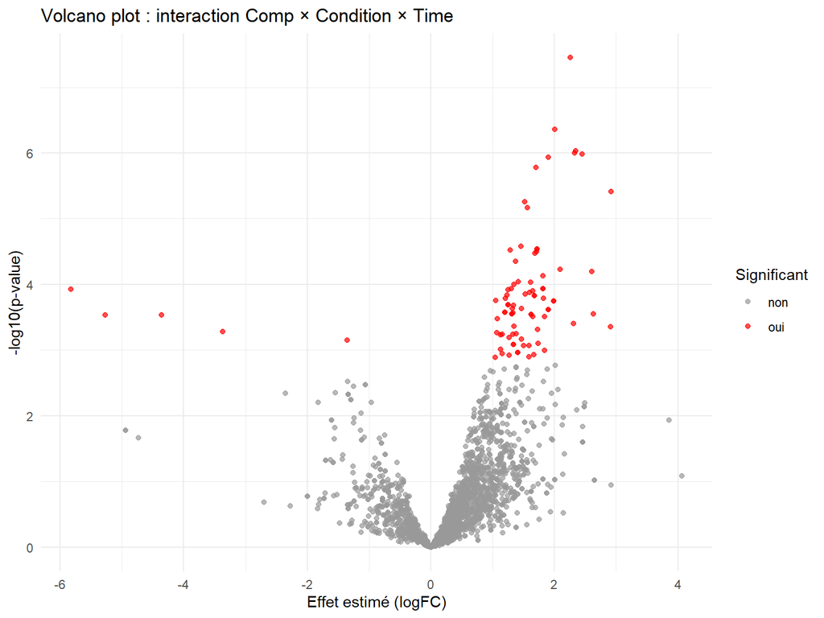

```r
res.triple$Significant <- ifelse(res.triple$adj.P.Val < 0.05, "oui", "non")

ggplot(res.triple, aes(x = logFC, y = -log10(P.Value), color = Significant)) +
  geom_point(alpha = 0.7) +
  scale_color_manual(values = c("non" = "grey60", "oui" = "red")) +
  theme_minimal() +
  labs(
    title = "Volcano plot : interaction Comp × Condition × Time",
    x = "Effet estimé (logFC)",
    y = "-log10(p-value)"
  )
```

## 13.2 Visualiser le profil d’un peptide significatif

Nous sélectionnons ici automatiquement le peptide le plus significatif pour le test principal.  
Cela permet d’illustrer concrètement, sur un exemple, ce que signifie une interaction triple significative.

```r
top_peptide <- res.triple$Peptide[which.min(res.triple$adj.P.Val)]
top_peptide
```

```
## [1] "9912____1"
```

Ce graphique montre le profil du peptide sélectionné, en comparant :

- le signal PTM ;
- le signal protéique ;

dans les deux conditions et aux deux temps.

L’objectif est de visualiser directement la structure que le modèle a détectée statistiquement.  
Ce type de représentation est très utile pour interpréter biologiquement un résultat significatif.

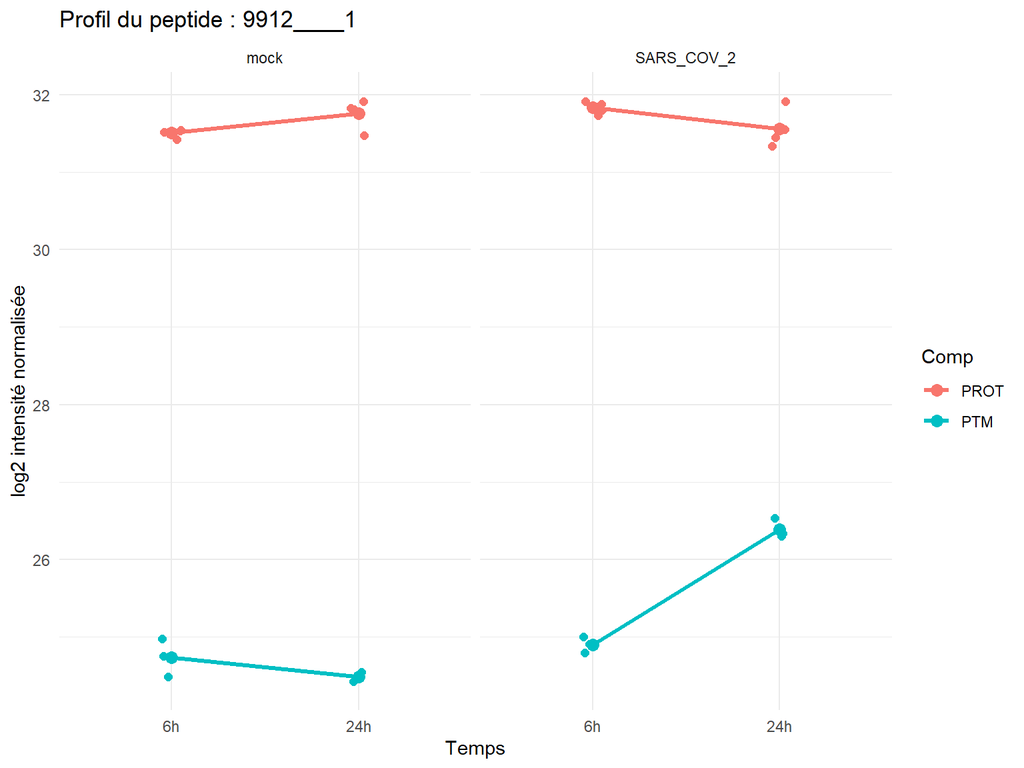

```r
i_top <- which(rownames(global.mat.complete) == top_peptide)

plot.df <- data.frame(
  value = as.numeric(global.mat.complete[i_top, ]),
  Comp = Comp,
  Condition = Condition,
  Time = Time
)

ggplot(plot.df, aes(x = Time, y = value, color = Comp, group = Comp)) +
  geom_point(position = position_jitter(width = 0.05), size = 2) +
  stat_summary(fun = mean, geom = "line", linewidth = 1.2) +
  stat_summary(fun = mean, geom = "point", size = 3) +
  facet_wrap(~ Condition) +
  theme_minimal() +
  labs(
    title = paste("Profil du peptide :", top_peptide),
    x = "Temps",
    y = "log2 intensité normalisée"
  )
```

# 14. Interprétation du test principal

Le coefficient `CompPTM:ConditionSARS_COV_2:Time24h` mesure une **interaction triple**.

Il correspond à une logique de **différence de différences de différences** :

- variation entre `24h` et `6h` ;
- comparée entre `PTM` et `PROT` ;
- puis comparée entre `SARS_COV_2` et `mock`.

En pratique :

- **si le coefficient est positif**, cela signifie que l’augmentation temporelle du PTM relativement à la protéine est plus forte en condition `SARS_COV_2` qu’en condition `mock` ;
- **si le coefficient est négatif**, cela signifie que cette augmentation relative est plus faible, voire inversée.

C’est donc un test particulièrement pertinent pour mettre en évidence une régulation de PTM dépendante de l’infection.

# 15. Export des résultats

On peut ensuite exporter les résultats dans des fichiers texte tabulés.  
Cela facilite leur réutilisation pour :

- une annotation biologique ;
- un enrichissement fonctionnel ;
- un partage avec d’autres collaborateurs ;
- ou une visualisation dans un autre logiciel.

```r
write.table(res.triple,
            file = "resultats_limma_modele_global_interaction_triple.txt",
            sep = "\t", quote = FALSE, row.names = FALSE)

write.table(res.comptime,
            file = "resultats_limma_modele_global_comp_time.txt",
            sep = "\t", quote = FALSE, row.names = FALSE)

write.table(res.compcond,
            file = "resultats_limma_modele_global_comp_condition.txt",
            sep = "\t", quote = FALSE, row.names = FALSE)
```

# 16. Conclusion

À partir de sorties MaxQuant, nous avons effectué une analyse multifactorielle permettant d’identifier des peptides modifiés dont la dynamique diffère de celle de leur protéine d’appartenance.

Le modèle global utilisé ici permet d’aller au-delà d’une simple comparaison par condition en testant directement si la relation entre PTM, protéine, temps et infection varie de manière significative.

# 17. Références

- Giai Gianetto Q. *Statistical Analysis of Post-Translational Modifications Quantified by Label-Free Proteomics Across Multiple Biological Conditions with R: Illustration from SARS-CoV-2 Infected Cells.* Methods in Molecular Biology, 2023.
- Ritchie ME et al. *limma powers differential expression analyses for RNA-sequencing and microarray studies.* Nucleic Acids Research, 2015.
- Tyanova S, Temu T, Cox J. *The MaxQuant computational platform for mass spectrometry-based shotgun proteomics.* Nature Protocols, 2016.